# MVA Assignment2

Sai Madhuri

2024-02-19

## R Markdown

##### Assignment2

```r
file_path <- "/Users/user/Downloads/KCLT.csv"
data <- read.csv(file_path)
weather_data <- read.csv("/Users/user/Downloads/KCLT.csv")
str(weather_data)
```

```
## 'data.frame':    365 obs. of  13 variables:
##  $ date                 : chr  "2014-7-1" "2014-7-2" "2014-7-3" "2014-7-4" ...
##  $ actual_mean_temp     : int  81 85 82 75 72 74 79 83 80 78 ...
##  $ actual_min_temp      : int  70 74 71 64 60 61 67 72 71 71 ...
##  $ actual_max_temp      : int  91 95 93 86 84 87 91 94 89 85 ...
##  $ average_min_temp     : int  67 68 68 68 68 68 68 68 68 68 ...
##  $ average_max_temp     : int  89 89 89 89 89 89 89 89 89 89 ...
##  $ record_min_temp      : int  56 56 56 55 57 57 55 58 57 53 ...
##  $ record_max_temp      : int  104 101 99 99 100 99 100 101 101 101 ...
##  $ record_min_temp_year : int  1919 2008 2010 1933 1967 1964 1972 1892 1891 1961 ...
##  $ record_max_temp_year : int  2012 1931 1931 1955 1954 1948 1954 2010 1986 1926 ...
##  $ actual_precipitation : num  0 0 0.14 0 0 0 0 0 0.15 0 ...
##  $ average_precipitation: num  0.1 0.1 0.11 0.1 0.1 0.1 0.11 0.11 0.12 0.11 ...
##  $ record_precipitation : num  5.91 1.53 2.5 2.63 1.65 1.95 2.37 1.87 3.71 2.45 ...
```

##### Univariate Analysis

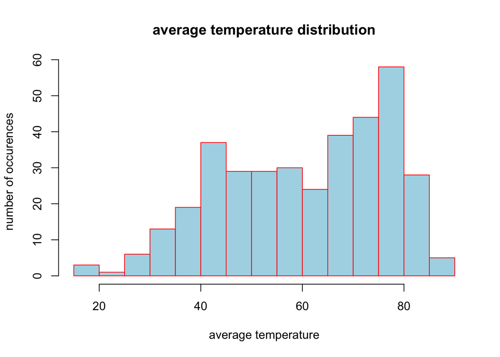

```r
#How is the distribution of actual mean temperature?

library(ggplot2)
hist(weather_data$actual_mean_temp,
     main = "average temperature distribution",
     xlab = "average temperature",
     ylab = "number of occurences",
     col = "lightblue",
     border = "red")
```

#insights from the above histogram #From the above histogram we can understand the below points # 1.There are no extreme values(outliers) in the data # 2.There is a slight negative skewness(left-skewed) in the data # 3.The temperatures are normally distributed after 60.

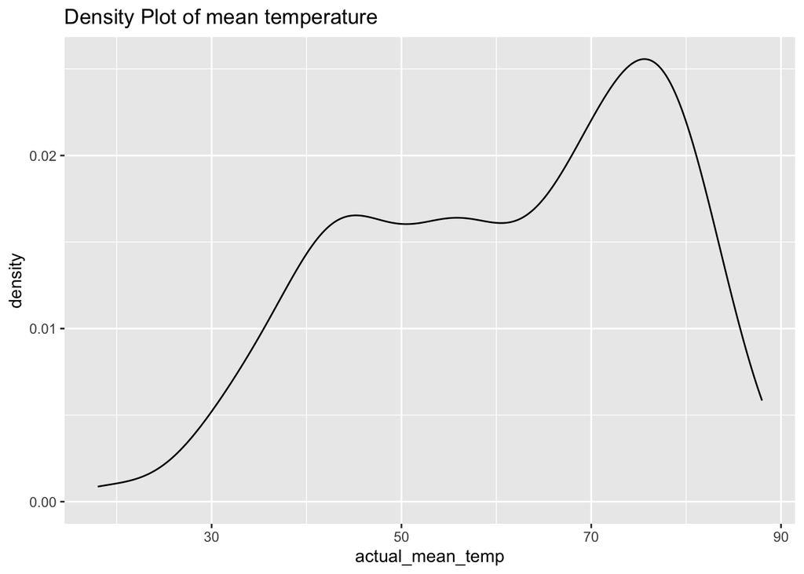

```r
#At what range most of the mean temperatures are clustered?
ggplot(weather_data, aes(x = actual_mean_temp)) +
  geom_density() +
  labs(title = "Density Plot of mean temperature")
```

#From the density plot we got a smooth estimate of the probability density function which tells that most the average temperatures lies between the range 40-80.